# Chapter 11 — Power (R companion)

R/tidyverse translation of *Understanding Data by Alan Garfinkel and Yina Guo

Adrian Soto-Mota, MD, PhD, FACP.

2026-04-24

# Orientation

Chapter 11 (book pp. 557–594) defines **statistical power** — the probability of detecting a real effect of a given size. Most underpowered studies don’t find what they should, and among underpowered studies that *do* find something, the effect is usually an exaggeration. This companion computes power by simulation (faithful to the book) and then via standard formulas.

## §11.1 — Two kinds of errors *(book §11.1 “The two types of errors”, p. 559)*

| Truth | If you Keep $H_0$ | If you Reject $H_0$ |
| --- | --- | --- |
| $H_0$ true | $\checkmark$ | **Type I** ($\alpha$) |
| $H_0$ false | **Type II** ($\beta$) | $\checkmark$ (power $= 1-\beta$) |

- **$\alpha$ (Type I rate)** — false alarm. Set by the analyst (commonly 0.05).
- **$\beta$ (Type II rate)** — missed real effect. We want this small.
- **Power** $= 1-\beta = P(\text{reject } H_0 \mid H_0 \text{ is false})$.

# §11.2 — Power by simulation *(book §11.2 “How to calculate the power of a study?”, p. 565)*

**Procedure** (for a two-sample t-test):

1. Pick a true effect size δ (e.g., mean difference of 0.3 SD).
2. Simulate many experiments at a given sample size.
3. Fraction of experiments where p < α is the power.

```r
simulate_power <- function(n_per_group, effect_size, alpha = 0.05,
                           n_sim = 2000, sigma = 1) {
  # In each iteration: simulate A and B, run t-test, record whether significant
  significant <- logical(n_sim)
  for (i in seq_len(n_sim)) {
    A <- rnorm(n_per_group, mean = 0,           sd = sigma)
    B <- rnorm(n_per_group, mean = effect_size, sd = sigma)
    significant[i] <- t.test(A, B)$p.value < alpha
  }
  mean(significant)
}

# Example: 30 per group, effect = 0.5 SD (Cohen's "medium")
simulate_power(n_per_group = 30, effect_size = 0.5)
```

```
## [1] 0.4615
```

Check against R’s built-in:

```r
library(pwr)   # install.packages("pwr")
pwr.t.test(n = 30, d = 0.5, sig.level = 0.05,
           type = "two.sample", alternative = "two.sided")$power
```

```
## [1] 0.4778965
```

Simulation and formula agree to within Monte Carlo noise (expected).

## §11.2 — Factors affecting power *(book §11.2 “Factors affecting the power of a study”, p. 571)*

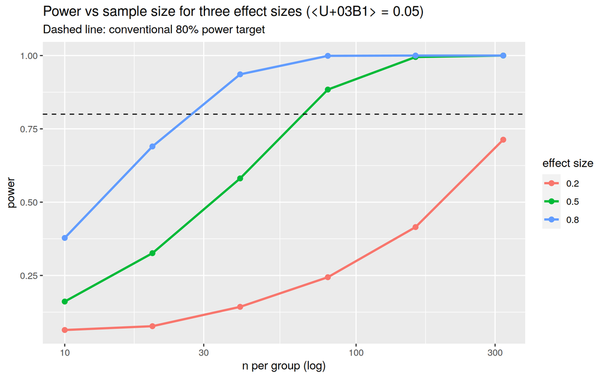

```r
grid <- expand_grid(
  n_per_group = c(10, 20, 40, 80, 160, 320),
  effect_size = c(0.2, 0.5, 0.8)     # Cohen's d: small, medium, large
) |>
  rowwise() |>
  mutate(power = simulate_power(n_per_group, effect_size, n_sim = 1000)) |>
  ungroup()

ggplot(grid, aes(n_per_group, power, color = factor(effect_size))) +
  geom_line(linewidth = 1) + geom_point(size = 2) +
  geom_hline(yintercept = 0.80, linetype = "dashed") +
  scale_x_log10() +
  labs(title = "Power vs sample size for three effect sizes (α = 0.05)",
       subtitle = "Dashed line: conventional 80% power target",
       x = "n per group (log)", y = "power",
       color = "effect size")
```

Three lessons: - Larger samples → more power (`power ∝ √n` at fixed δ). - Larger effects → easier to detect. - Small effects (d = 0.2) need **huge** samples (n ≈ 400 per group for 80 % power).

# §11.3 — A low-power study wrongly concluding “no effect” *(book §11.3 “Was Bendectin use by pregnant women associated with an increased risk of birth defects?”, p. 577)*

The chapter uses as an example the **Bendectin** controversy: an underpowered study found no increase in birth defects and was read as exonerating the drug. Let’s simulate what that looks like.

```r
# Suppose the true relative risk is 1.3 (a real but modest harm).
# A small study of 200 exposed + 200 unexposed may fail to detect it.

simulate_bendectin <- function(n_exposed, n_unexposed,
                               baseline_risk, true_rr, n_sim = 1000) {
  significant <- logical(n_sim)
  for (i in seq_len(n_sim)) {
    exposed   <- rbinom(1, n_exposed,   baseline_risk * true_rr)
    unexposed <- rbinom(1, n_unexposed, baseline_risk)
    tab <- matrix(c(exposed,   n_exposed   - exposed,
                    unexposed, n_unexposed - unexposed),
                  nrow = 2, byrow = TRUE)
    significant[i] <- chisq.test(tab)$p.value < 0.05
  }
  mean(significant)
}

# Baseline risk 3%, true RR 1.3
simulate_bendectin(n_exposed = 200, n_unexposed = 200,
                   baseline_risk = 0.03, true_rr = 1.3)
```

```
## [1] 0.043
```

Power is embarrassingly low. The study “found nothing” because it couldn’t find anything of that magnitude — not because nothing was there.

```r
# With bigger samples, power rises
tibble(
  n = c(200, 500, 1000, 2000, 5000),
  power = map_dbl(n, \(n) simulate_bendectin(n, n, 0.03, 1.3, n_sim = 500))
)
```

```
## # A tibble: 5 x 2
##       n power
##   <dbl> <dbl>
## 1   200 0.042
## 2   500 0.07
## 3  1000 0.186
## 4  2000 0.286
## 5  5000 0.67
```

**A null result is not evidence of no effect unless the power was high.**

# §11.4 — Prospective power (sample-size planning) *(book §11.4 “The prospective importance of power”, p. 588)*

The right question at design time: “what n do I need to detect δ at α and power 1 − β?”

```r
# What n per group gives 80% power to detect d = 0.5 at α = 0.05?
pwr.t.test(d = 0.5, sig.level = 0.05, power = 0.80,
           type = "two.sample")
```

```
##
##      Two-sample t test power calculation
##
##               n = 63.76561
##               d = 0.5
##       sig.level = 0.05
##           power = 0.8
##     alternative = two.sided
##
## NOTE: n is number in *each* group
```

```r
# By simulation:
ns <- seq(30, 100, by = 5)
powers <- map_dbl(ns, \(n) simulate_power(n, 0.5, n_sim = 1000))
tibble(n = ns, power = powers)
```

```
## # A tibble: 15 x 2
##        n power
##    <dbl> <dbl>
##  1    30 0.476
##  2    35 0.565
##  3    40 0.609
##  4    45 0.68
##  5    50 0.717
##  6    55 0.741
##  7    60 0.761
##  8    65 0.808
##  9    70 0.822
## 10    75 0.863
## 11    80 0.876
## 12    85 0.885
## 13    90 0.92
## 14    95 0.917
## 15   100 0.936
```

Both approaches agree on ≈ 64 per group.

# §11.5 — Power and the credibility of positive results *(book §11.5 “Role of power in positive results”, p. 589)*

The “winner’s curse”: if your study was barely powered, a positive result is **biased upward** — the effect you measure is bigger than the true effect.

```r
true_effect <- 0.3
n_per_group <- 30            # this yields low power (~0.22)
n_sim       <- 5000

# Plain loop is faster and clearer than rowwise() with list columns
p_values <- numeric(n_sim)
d_hats   <- numeric(n_sim)
for (i in seq_len(n_sim)) {
  A <- rnorm(n_per_group, 0,           1)
  B <- rnorm(n_per_group, true_effect, 1)
  tt <- t.test(A, B)
  p_values[i] <- tt$p.value
  d_hats[i]   <- mean(B) - mean(A)
}
results <- tibble(p = p_values, d_hat = d_hats)

# Average effect among ALL studies vs among "significant" studies
tibble(
  pool              = c("All studies", "Significant at p < 0.05"),
  mean_measured_d   = c(mean(results$d_hat),
                        mean(results$d_hat[results$p < 0.05]))
)
```

```
## # A tibble: 2 x 2
##   pool                    mean_measured_d
##   <chr>                             <dbl>
## 1 All studies                       0.306
## 2 Significant at p < 0.05           0.653
```

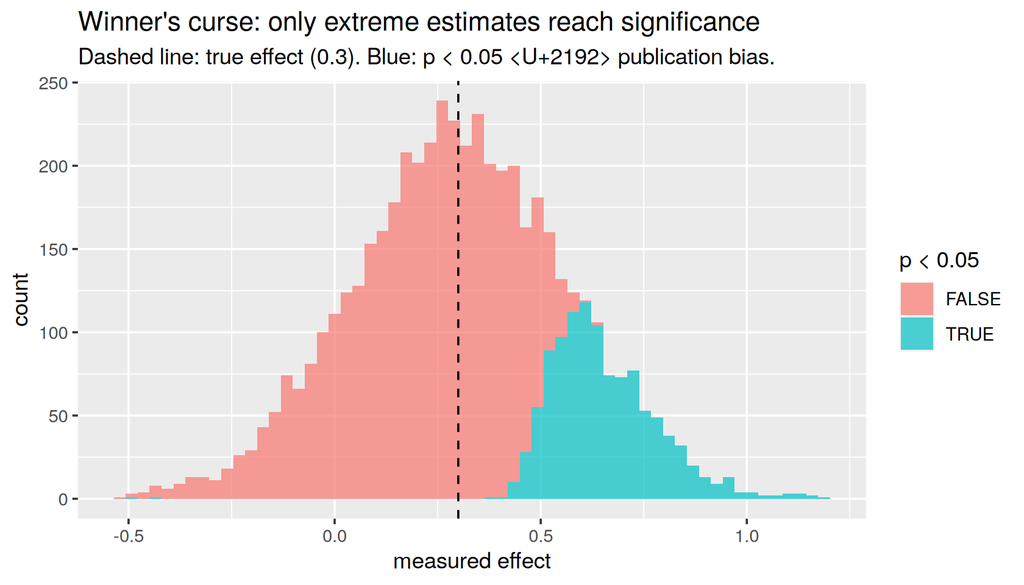

```r
ggplot(results, aes(d_hat, fill = p < 0.05)) +
  geom_histogram(bins = 60, alpha = 0.7) +
  geom_vline(xintercept = true_effect, linetype = "dashed") +
  labs(title = "Winner's curse: only extreme estimates reach significance",
       subtitle = "Dashed line: true effect (0.3). Blue: p < 0.05 → publication bias.",
       x = "measured effect", y = "count", fill = "p < 0.05")
```

# Exercises

1. Replicate the grid plot with α = 0.01 and α = 0.001. How much larger must samples be to recover the same 80 % power?
2. Simulate a chi-square power analysis: true OR = 2, baseline risk 0.1. What `n` per arm is needed for 80 % power?
3. Run the winner’s curse simulation with `n_per_group = 200` (high power). Is the publication bias still present? At what power level does it vanish?